# Good Vs Evil: A Data Story of Superheroes and Villians

## By: Apoorva Gundu

[figure not shown]

#### **My Story:**

My only interaction with the Marvel and DC universe was through movies. I am a huge fan of Batman but I never read the comic books. When I was looking this particular data, I kept thinking about what questions I wanted to ask. Then I turned to my own life. Within Indian culture and Hinduism, we are told about this value called *"Dharma"* which is essentially about good always winning over bad. This is applied to mythical stories where the villians are always killed by heroes. So I wanted to explore how Marvel and DC dealt with villians and heroes defeating them. The following questions were designed to analyze how good and bad characters were introduced and details of those characters.

#### **Where is the data coming from:**

The data was collected by Walt Hickey, who was the chief culture writer for FiveThirtyEight. This data was first used for his article, *"Comic Books Are Still Made By Men, For Men, About Men"* in October 2014. The data comes from Marvel Wikia and DC Wikia. The month and year of the first issue each character appeared in was pulled on October 6, 2014. This data also includes information on gender, alignment, identity status, appearances and many other attributes for characters across Marvel and DC universes. For the purpose of this project, the graphs plot specific data for male and female genders. For certain dataframes, there were specific variables omitted to make the data specific and concise. There was also data known as "ND" that was omitted from the graphs for the purpose of data cleaning.

[figure not shown]

### **Computational Thinking**

In this project, I was able to use computational thinking perspectives and practices to explore my questions. With the perspective of expressing, the code used to create the graphs allowed me to express myself through making the plots unique to me. With the use of various kinds of graphs and various colors, I was able to create plots that looked unique and conveyed the information clearly. I was also able to see data through complex concepts that allowed me to compare multiple variables at a time quickly and visually. Through the perspective of connecting, I was able to make connections and draw conclusions from the data I found through specific conditions.

While many computational practices were used for this project, the main ones that I used the most were experimenting and reiterating as well as testing and debugging. My biggest challenge of this project was cleaning the data. Through experimenting and reiterating, I was able to clean data for various data frames and be able to simplify the data that I was working with. No coding project goes well without our friendly errors. Testing and debugging was a practice that became second nature to coding and it was actually fun to solve problems throughout my code, especially when you get an error for missing an extra pararenthesis.

```python
import pandas as pd
import numpy as np
import matplotlib.pyplot as plt

%matplotlib inline

plt.rcParams["figure.figsize"] = (8, 6)
```

```python
superfemale = pd.read_csv("~/Documents/INFO1201/Mod 5 Visualizing Data/superhero_data_copy.csv", parse_dates = ["FIRST_YEAR"])
```

#### **Question 1**

##### *What is the alignment of the new characters introduced by year?*

For the opening question, I first wanted to know how many bad and good characters were introduced over the years and to see the trend of each alignment. I started with the .valuecounts() to see how many alignment characters were there. Based on data from the output, I decided to remove ND (No Data) and Reformed Criminals from the dataset. This decision was made because I only wanted to know about bad and good criminals and the numbers for Reformed criminals were very low and almost non-existent when graphed. I included neutral characters because I was surprised to see the number of those characters being introduced to be more than what I expected. The removal of ND and Reformed Criminals data did not affect my graph significantly.

I used pd.crosstab to analyze the data and used the .replace and .drop function to clean the data frame. I chose a line graph because it was the best way to see the data across time and also visually represented the numbers for the data.

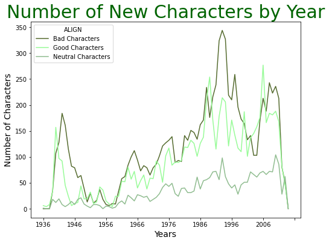

```python
years= superfemale

years= years.replace("ND", "Delete")
#years = years.replace("Neutral Characters", "Delete")
years = years.replace("Reformed Criminals", "Delete")
years_new= years.drop(years[years.ALIGN== "Delete"].index)
years_new= years_new.replace("ND", "Delete")
old_years= years_new.drop(years_new[years_new.FIRST_YEAR== "Delete"].index)

prettyyears= pd.crosstab(old_years['FIRST_YEAR'], old_years['ALIGN'])
prettyyears.plot(color=([ "darkolivegreen", "palegreen", "darkseagreen",]))
plt.title("Number of New Characters by Year", fontsize= 30, loc= "center", color= "darkgreen")
plt.xlabel("Years", fontsize = 14)
plt.ylabel("Number of Characters", fontsize = 14)
plt.show()
```

##### *Analysis*

The overall trend that I noticed almost immediately was that bad characters were introduced more than good characters. In the graph, you can see that the most amount of bad characters introduced was between 1986-1996. The good characters did follow the same trend as bad characters; however, it was still not as much as the bad characters. It about about 100 characters less than bad characters.

#### **Question 2**

##### *What is the alignment of characters in each universe?*

After seeing the trend through the years, I now wanted to know which universe was creating the most good and bad characters. For this data frame, I included reformed criminals and neutral characters. Even though the reformed criminals bar is not seen, there was data present and I thought that it was still important to include. The only data that was omitted was ND because it did not provide anything useful for the purpose of this graph.

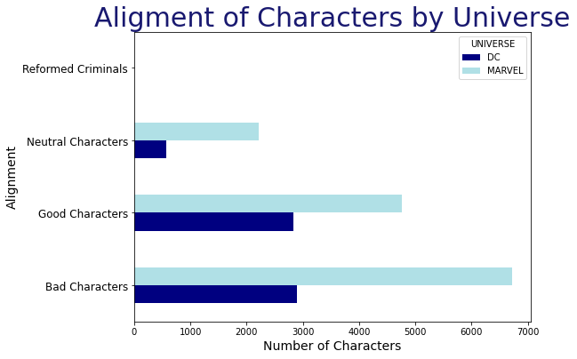

```python
align= superfemale.drop(superfemale[superfemale.ALIGN== "ND"].index)
#date= align["ALIGN"].value_counts()
#print(date)

evil_characters= pd.crosstab(align["ALIGN"], align["UNIVERSE"])
evil_characters.plot(kind = 'barh', color=(["navy", "powderblue"]))
plt.title("Aligment of Characters by Universe", fontsize = 30, loc= "center", color= "midnightblue")
plt.xticks(rotation = 0, fontsize = 10)
plt.yticks(fontsize = 12)
plt.xlabel("Number of Characters", fontsize = 14)
plt.ylabel("Alignment", fontsize = 14)
plt.show()
```

##### *Analysis*

I was very surprised with this result. Marvel introdcued the most bad characters and good characters. They introduced 2000 more bad characters than good characters. They also introduced more neutral characters than DC. DC introduced bad and good characters equally with bad characters slightly more.

#### **Question 3**

##### *How many male and female characters have a secret identity versus a public identity?*

Shifting gears, I wanted to explore if gender played a factor into the identity status of characters. For this particular data frame, I had to omitted ND, Agender, Genderfluid and Genderless characters because I wanted to focus solely on gender binary characters. With identity status, I added Nathaniel Richards into the secret identity category after completing a simple search for that character. The ND for the ID dataframe was also removed.

I used pd.crosstab to analyze the data and used the .replace and .drop function to clean the data frame. I chose a bar graph because it was the best way to see the difference between the two genders and see the variety within the multiple bars.

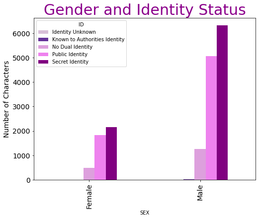

```python
#female= superfemale["SEX"].value_counts()
#print(female)
change_gender = superfemale
change_gender= change_gender.replace("Male Characters", "Male")
change_gender= change_gender.replace("Male Character", "Male")
change_gender= change_gender.replace("Female Characters", "Female")
change_gender= change_gender.replace("Female Character", "Female")
change_gender= change_gender.replace("ND", "Delete")
change_gender= change_gender.replace("Agender Characters", "Delete")
change_gender= change_gender.replace("Genderfluid Characters", "Delete")
change_gender= change_gender.replace("Genderless Characters", "Delete")
new_gender= change_gender.drop(change_gender[change_gender.SEX == "Delete"].index)
new_gender= new_gender.replace("Nathaniel Richards", "Secret Identity")
newi_gender= new_gender.drop(new_gender[new_gender.ID== "Delete"].index)


male= pd.crosstab(newi_gender["SEX"], newi_gender["ID"])
male.plot(kind="bar", fontsize=14, color=(["thistle","rebeccapurple", "plum","violet", "purple"]))
plt.title("Gender and Identity Status", fontsize = 30, loc= "center", color= "darkmagenta")
plt.ylabel("Number of Characters", fontsize = 14)
plt.show()
```

#### **Question 4**

##### *How many bad characters have a secret identity as compared to good characters by gender?*

With this question, I wanted to combine previous data exploration and visually analyze the data around identity status, alignment and gender. For this particular data frame, I had to omitted ND, Agender, Genderfluid and Genderless characters because I wanted to focus solely on gender binary characters. With alignment dataframe, I removed ND, Neutral characters and Reformed criminals to soley focus on good and bad characters.

I used pd.crosstab to analyze the data and used the .replace and .drop function to clean the data frame. I chose a stacked bar graph because it best represented the crosstab data of multiple variables and one can visually see the differences in data.

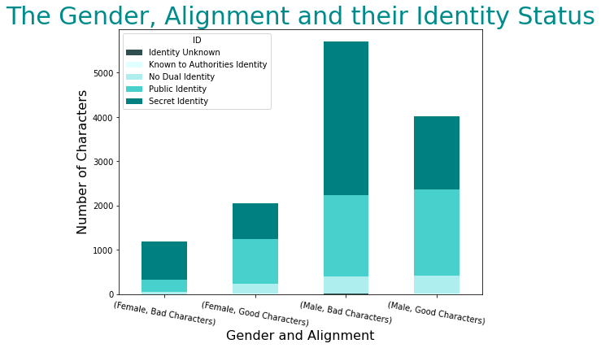

```python
updated_superfemale = superfemale

updated_superfemale = updated_superfemale.replace("Nathaniel Richards", "Secret Identity")
updated_superfemale = updated_superfemale.replace("ND", "Delete")
update = updated_superfemale.drop(updated_superfemale[updated_superfemale.ID == "Delete"].index)

update= update.replace("Male Characters", "Male")
update= update.replace("Male Character", "Male")
update= update.replace("Female Characters", "Female")
update= update.replace("Female Character", "Female")
update= update.replace("ND", "Delete")
update= update.replace("Agender Characters", "Delete")
update= update.replace("Genderfluid Characters", "Delete")
update= update.replace("Genderless Characters", "Delete")
update_again= update.drop(update[update.SEX== "Delete"].index)

update_again= update_again.replace("ND", "Delete")
update_again = update_again.replace("Neutral Characters", "Delete")
update_again = update_again.replace("Reformed Criminals", "Delete")
update_onceagain= update_again.drop(update_again[update_again.ALIGN== "Delete"].index)


evil_understood= pd.crosstab(index= [update_onceagain["SEX"], update_onceagain["ALIGN"]], columns = [update_onceagain["ID"]])
evil_understood.plot(kind = 'bar', stacked = True, color=(["darkslategrey", "lightcyan", "paleturquoise","mediumturquoise", "teal"]))

plt.title("The Gender, Alignment and their Identity Status", fontsize = 30, loc= "center", color= "darkcyan")
plt.xticks(rotation=-10, fontsize = 10)
plt.yticks(fontsize = 10)
plt.xlabel("Gender and Alignment", fontsize = 16)
plt.ylabel("Number of Characters", fontsize = 16)
plt.show()
```

##### *Analysis*

Based on this graph, male and bad characters were had the most amount of characters as we observed before. In this category, there are more characters with a secret identity. For female characters, there are more bad characters whose identities are secret than public compared to good characters.

#### **Question 5**

##### *How many bad characters are dead or alive by gender?*

For the final question, I wanted to know if bad characters were often killed by the good characters. For this particular data frame, I had to omitted ND, Agender, Genderfluid and Genderless characters because I wanted to focus solely on gender binary characters. With alignment, I also omitted ND data points.

I used pd.crosstab to analyze the data and used the .replace and .drop function to clean the data frame. I chose a stacked bar graph because it best represented the crosstab data of multiple variables and one can visually see the differences in data.

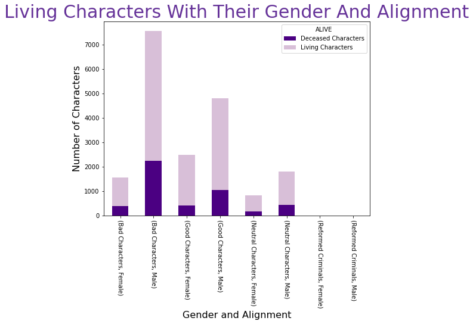

```python
alive= superfemale
alive= alive.replace ("ND", "Delete")
alive= alive.replace ("Male Character", "Male")
alive= alive.replace ("Male Characters", "Male")
alive= alive.replace ("Female Characters", "Female")
alive= alive.replace ("Agender Characters", "Delete")
alive= alive.replace ("Genderfluid Characters", "Delete")
alive= alive.replace ("Transgender Characters", "Delete")
alive= alive.replace ("Genderless Characters", "Delete")
alive_one= alive.drop(alive[alive.SEX=="Delete"].index)
alive_one= alive_one.replace("ND", "Delete")
alive_two= alive_one.drop(alive_one[alive_one.ALIVE== "Delete"].index)
alive_two= alive_two.replace ("ND", "Delete")
alive_three= alive_two.drop(alive_two[alive_two.ALIGN== "Delete"].index)
aliveordead= pd.crosstab(index= [alive_three["ALIGN"], alive_three["SEX"]], columns= alive_three["ALIVE"])

aliveordead.plot(kind = 'bar', stacked = True, color=(["indigo","thistle"]))

plt.title("Living Characters With Their Gender And Alignment", fontsize = 30, loc= "center", color= "rebeccapurple")
plt.xticks(rotation=-90, fontsize = 10)
plt.yticks(fontsize = 10)
plt.xlabel("Gender and Alignment", fontsize = 16)
plt.ylabel("Number of Characters", fontsize = 16)

plt.show()
```

##### *Analysis*

[figure not shown]

### **Findings**

[figure not shown]

### **Acknowledgements**

THANK YOU to Shiva Darian for being an amazing instructor. This code was inspired by her superheroPlots_Skeleton and Comments_skeleton.

Thank you to the following websites: https://stackoverflow.com/questions/16006572/plotting-different-colors-in-matplotlib/45916274 - for code on how to use certain colors for the plots https://matplotlib.org/stable/gallery/color/named_colors.html - for the names of colors https://github.com/adam-p/markdown-here/wiki/Markdown-Cheatsheet - for markdown organization

[figure not shown]